# Summary Plots and Statistics for Drifting Buoy Sperm Whale Events

Summary tables and plots to aid in manual assessment of potential sperm whale events in drifting buoy data. Cpde adapted by Kourtney Burger for SWFSC CalCurCEAS 2024 drifter analysis

Kourtney Burger

29 May 2025

# Code source

Replicated code from Jenny Trickey’s repo [here](https://github.com/jtrickey86/SpermWhale_DASBR/blob/main/SpermWhale_event_summary_report_DASBR.Rmd)

## Trip/drift: CalCurCEAS_2024_014

Summaries generated: 2025 May 29 18:48 UTC

### Setup

Load needed libraries.

```r
# load all libraries
devtools::install_github('taikisan21/PAMpal')
library(PAMpal)
# library(kableExtra) # known bug with R ver 4.3.0 so install from github
devtools::install_github('kupietz/kableExtra')
library(kableExtra)
library(ggplot2)
library(RSQLite)
library(tuneR)
# library(wesanderson)
library(here)
library(DBI)

# I don't think we need these but saving here in case
library(dplyr)
# library(tcltk)
# library(manipulate)
```

Set user-defined variables.

```r
# name project
# ProjID <- 'MHI UxS Glider Project'

# combine trip, recorder, pg version (all defined in YAML) to single run string
# dbFileStr <- paste0(params$mission, '_', params$drift, '_Kogia_', params$pgver)

# define subfolder paths based on selected analysis folder and trip strings
# path_to_db <- file.path(params$path_pg, 'Database')
# path_to_binaries <- file.path(params$path_pg, 'Binaries', params$drift)
path_to_binaries <- choose.dir(default="", caption = "Select path to specific drift main binaries folder")
# assemble some file names
# pamguard database
# dbFile <- file.path(path_to_db, paste0(dbFileStr, '.sqlite3'))
dbFile <- file.choose()
# dbFile <- choose.files(default = "", caption = "Select database file", multi = FALSE)
# already processed acoustic study 'dets' file
detsFile <- file.path(params$path_dets, paste0(params$mission, '_', params$drift,'/', params$mission, '_2024_', params$drift, '_Filtered.rdata'))
detsFiltFile <- file.path(params$path_dets,
                          paste0(params$mission, '_', params$drift,'/', params$mission, '_2024_', params$drift, '_', params$channelStr, '.rdata'))
# specify calibration file
# calFile <- params$calFile # pull from YAML

# set path to reference spectra if will be used
path_to_refSpec <- file.path(params$path_to_refSpec) # pull from YAML
# specify which reference spectra to plot
# refSpecList = c('Gm', 'Pc')
refSpecList <- params$refSpecList # pull from YAML
refSpecSp <- params$refSpecSp


# ALTERNATIVE SELECT PATHS
# path_pg <- choose.dir(default = "", caption = "Select path to pamguard folder that contains databases and binaries folders")
# # select path to database files
# path_to_db <- choose.dir(default = "", caption = "Select path to folder with all database files")
# # select path to specific binary drift file
# path_to_binaries <- choose.dir(default="", caption = "Select path to specific drift main folder")

# # set up datebase driver
# sqlite <- dbDriver("SQLite") # outdated/no longer supported

# connect to SQLite database using the newer method
con <- dbConnect(RSQLite::SQLite(), dbname = dbFile)

#Set time zone to UTC
Sys.setenv(TZ = 'UTC')

# reference spectra colors - allows for up to 6 ref specs
# pastel
# rsPalette <- c('#66c2a5', '#fc8d62', '#8da0cb', '#e78ac3',
#                '#a6d854', '#ffd92f')
# bold
rsPalette <- c('#1b9e77', '#d95f02', '#7570b3', '#e7298a',
               '#66a61e', '#e6ab02')
```

#### Define needed functions

Source some external functions

```r
source(here::here('_code/functions', 'loadMultiBinaries.R'))
source(here::here('_code/functions', 'plotContours.R'))
source(here::here('_code/functions', 'clickSummary.R'))
source(here::here('_code/functions', 'whistleSummary.R'))

# if not using Rproj/here package use:
# source(file.path(params$path_code, 'R', 'functions', 'loadMultiBinaries.R'))
```

#### Load and prep AcousticStudies

If already created, load an existing `dets` PAMpal AcousticStudy object for event processing. We need to load both the unfiltered `dets` and filtered `detsFilt` AcousticStudies.

```r
# load existing dets AcousticStudy (created with
# workflow_generate_acousticStudies.R)
# load(detFile)
if (file.exists(detsFile)){
  dets <- readRDS(detsFile)
  cat('Loaded', detsFile, '\n')
} else {
  cat('No AcousticStudy \'dets\' file available', '\n')
}
```

```
## Loaded Z:/drifting_recorder/2_Acoustic-Studies/2024_CalCurCEAS/CalCurCEAS_014/CalCurCEAS_2024_014_Filtered.rdata
```

```r
if (file.exists(detsFiltFile)){
  detsFilt <- readRDS(detsFiltFile)
  cat('Loaded', detsFiltFile, '\n')
} else {
  cat('No AcousticStudy \'detsFilt\' file available', '\n')
}
```

```
## Loaded Z:/drifting_recorder/2_Acoustic-Studies/2024_CalCurCEAS/CalCurCEAS_014/CalCurCEAS_2024_014_ch1.rdata
```

```r
# summarize how many events
nEvents <- length(names(PAMpal::events(dets)))
# number of events may change after filtering (all clicks may be filtered out)
nEventsFilt <- length(names(PAMpal::events(detsFilt)))
```

Loaded Z:/drifting_recorder/2_Acoustic-Studies/2024_CalCurCEAS/CalCurCEAS_014/CalCurCEAS_2024_014_Filtered.rdata and Z:/drifting_recorder/2_Acoustic-Studies/2024_CalCurCEAS/CalCurCEAS_014/CalCurCEAS_2024_014_ch1.rdata

[output not shown]

[output not shown]

Updated file paths to binaries in databases for Z:/drifting_recorder/2_Acoustic-Studies/2024_CalCurCEAS/CalCurCEAS_014/CalCurCEAS_2024_014_Filtered.rdata and Z:/drifting_recorder/2_Acoustic-Studies/2024_CalCurCEAS/CalCurCEAS_014/CalCurCEAS_2024_014_ch1.rdata

#### Create initial output Event Table CSV

To be used for manual scoring based on report figures.

```r
# set up output data frame
evTable <- data.frame(drift = character(nEvents), id = character(nEvents),
                      species = character(nEvents), numClicks = numeric(nEvents))
# populate with drift string and event names
evTable$drift <- paste0(params$mission, '_', params$drift)
evTable$id <- names(PAMpal::events(detsFilt))

# get all click data
allClks <- PAMpal::getClickData(detsFilt)
# get the number of clicks for each event
for (iEvent in c(1:nEventsFilt)){
  evTable$numClicks[iEvent] <- length(which(allClks$eventId == evTable$id[iEvent]))
}

# keep only rows/events with at least 200 clicks
evTable <- evTable[which(evTable$numClicks >199),]

# add column for keeping/removing based on median peak frequency
evTable$keep <- FALSE # set all to false, will mark keepers as TRUE in loop

# save event table as CSV
write.csv(evTable, file = file.path(params$path_dets,
                                    paste0('eventTable_', params$mission, '_',
                                           params$drift, '_', Sys.Date(),'.csv')))
```

**712 events** (files) in drift. **12 events** have at least 200 clicks. Additional events may be removed if the median peak frequency of all high SNR clicks is less than 6 kHz. The final number of events can be found at the very end of the report.

#### Load reference spectra, if specified

Load the reference spectra for plotting, if set with `refSpecList`.

```r
# refSpecList is specified in YAML params. Can be one or multiple species
# for single species specify as char string without quotations e.g., refSpecPc
# for multiple species, specify with call to R and c()
#     e.g., !r c('meanSpecGm', 'refSpecPc_LLHARP')

refSpecs <- NULL
if (!is.null(refSpecList)){
  refSpecs = list()
  for (rs in refSpecList){
    refSpecs[[rs]] = read.csv(file.path(path_to_refSpec, paste0(rs, '.csv')))
  }
}
```

### Event summaries

Loop through each detection event (n = 12) create plots and a table of summary statistics for click and whistle detections. This process uses AcousticStudy objects that have detection data for each event, and also pulls information from the Pamguard binaries associated with each AcousticStudy.

Click plots (other than the SNR plot) only show clicks with SNRs >= 15 dB.

```r
for (iEvent in c(1:nEventsFilt)){
  # iEvent = 6 # for testing
  # ("pagebreak \n")

  # extract this event UID string
  eventList <- PAMpal::events(detsFilt)
  eventUID <- names(eventList)[iEvent]

  ###### summarize clicks ######
  cl <- clickSummary(detsFilt, eventUID)

  if ((cl$nClicks > 199) && median(cl$goodClicks$peak, na.rm = TRUE) >= 6){
    # keep this in evTable
    evTable$keep[evTable$id == eventUID] <- TRUE
    evTable$medPeakFrq[evTable$id == eventUID] <- median(cl$goodClicks$peak,
                                                         na.rm = TRUE)

    # set header for this event and print time
    cat('\n\n#### Event ID:   ', names(eventList)[iEvent], '\n')
    cat('Time:   ', format(eventList[[eventUID]]@ancillary$grouping$start,
                           '%Y-%m-%d %H:%M%Z'), ' to ',
        format(eventList[[eventUID]]@ancillary$grouping$end, '%Y-%m-%d %H:%M%Z'),
        '\n')

    cat('\nEvent contains', nrow(PAMpal::getClickData(dets[[eventUID]])),
        'original clicks,', paste0('**', cl$nClicks), 'valid clicks** after',
        'filtering.\n')
    cat('\n')

    ###### summarize whistles ######
    # wl <- whistleSummary(detsFilt, eventUID)
    #
    # cat('\nEvent contains', paste0('**', wl$nWhistles), 'whistles**.\n')
    # cat('\n')

    ###### click plots and table ######

    cat('\n##### Click plots and table\n')
    cat('\n SNR histogram includes all filtered clicks. Other plots contain only',
        'clicks with SNR >= 15 dB', paste0('(**n = ', cl$nGoodClicks, ' clicks**)'),
        '.\n')
    cat('\n')


    # if any clicks...
    if (cl$nClicks > 0){
      # histogram of all clicks and SNR >= 15 dB cut off
      xMax <- max(c(15, ceiling(max(cl$snr)) + 2)) # whichever is bigger
      if (any(!is.na(cl$snr))){
        hist(cl$snr, breaks = seq(from = floor(min(cl$snr)),
                                  to = xMax, by = 2),
             main = 'Click SNR', sub = '(all filtered clicks)', xlab = 'SNR')
        abline(v = 15, lty = 2, lwd = 2, col = 'red4')
      }

    }

    # if sufficient good clicks...
    if (cl$nGoodClicks > 0) {
      # histogram of click durations - good clicks only
      subStr <- paste0('(high SNR clicks, n=', cl$nGoodClicks, ')')
      hist(cl$goodClicks$duration,
           breaks = seq(from = 0, to = max(cl$goodClicks$duration) + 100,
                        by = 100), main = 'Click duration', sub = subStr,
           xlab = expression(paste('duration [', mu, 's]')))
      abline(v = median(cl$goodClicks$duration), lty = 2, lwd = 2, col = 'black')
      legend('topright', legend = 'median', lty = 2, lwd = 2, col = 'black')


      cat('\n')
      cat('\n')


      # Calculate and plot Concatenated and Mean Spectrum for clicks w/ max SNR > 15dB
      # NB: JLKM uses more exaggerated SNR (>40 dB) for BWs bc actual spectra may
      # be noisy for single clicks
      # reducing wl can give more accurate noise floor but 'smoother' spectrum
      # increasing wl will give more exact spectrum but may exclude too many
      # clicks based on SNR (noise measure will overlap with click output; noise
      # is just measured as same wl from start of binary snippet and binaries
      # binary snippets are v short)
      # Trial and error - 256 works ok for LLHARP data = 1.28 ms
      # NB: JLKM uses 500 for beaked whales with samp rate 288k
      avgSpec <- PAMpal::calculateAverageSpectra(detsFilt, evNum = eventUID, wl = 256,
                                         channel = params$channelNum, norm = TRUE,
                                         noise = TRUE, sort = TRUE, snr = 15,
                                         plot = c(TRUE, FALSE))
      # concatenated spectrogram will get plotted within calculation

      # avg spectrum plots separately (bc adding stuff)
      if (!is.null(avgSpec)) {
        # Peak freq as calculated by calculateAvgerageSpectra -for subtitle
        peakFreq <- round(avgSpec$freq[which.max(avgSpec$avgSpec)]/1000, 2)

        plot(1, type = 'n', xlim = c(0, 100), ylim = c(min(avgSpec$avgSpec), 0),
             xlab = 'Frequency (kHz)', ylab = 'Normalized Magnitude (dB)',
             main = 'Average Spectrum', sub = paste0('Peak: ', peakFreq, 'kHz'))
        # add grid lines for frequency at 10 kHz intervals
        for (iline in ((0:20)*10)) {lines(c(iline,iline), c(-100,10), col="gray")}
        # add template spectra
        if (length(refSpecs) > 0){
          rsCols <- rsPalette[1:length(refSpecs)]
          for (rs in 1:length(refSpecs)){
            rsTmp <- refSpecList[rs]
            rsNorm <- refSpecs[[rsTmp]]
            rsMax <- max(rsNorm$dB)
            rsNorm$dBNorm <- rsNorm$dB - rsMax
            lines(rsNorm$frq, rsNorm$dBNorm, col = rsCols[rs], lwd = 2)
          }
        }

        # plot noise
        lines(avgSpec$freq/1000, avgSpec$avgNoise, lty = 3, lwd = 2)
        # plot avg spectrum
        lines(avgSpec$freq/1000, avgSpec$avgSpec, lty = 2, lwd = 3)
        # also plot median spectrum
        medSpec <- 20*log10(apply(avgSpec$allSpec, 1, function(y) {
          median(10^(y/20), na.rm = TRUE)}))
        medSpecNorm <- medSpec - max(medSpec, na.rm = TRUE)
        lines(avgSpec$freq/1000, medSpecNorm, lty = 1, lwd = 3)

        # add legend
        if (length(refSpecs) > 0){
          legend(x = 'topright', c(refSpecSp, 'Avg.', 'Med.', 'Noise'),
                 lty = c(rep(1, length(refSpecs)), 2, 1, 3),
                 lwd = c(rep(1, length(refSpecs)), 2, 3, 2),
                 col = c(rsCols, 'black', 'black', 'black'), cex = 0.8)
        } else if (length(refSpecs) == 0){
          legend(x = 'topright', c('Avg.', 'Med.', 'Noise'),
                 lty = c(2, 1, 3), lwd = c(2, 3, 2),
                 col = c('black', 'black', 'black'), cex = 0.8)
        }
      }


      # NB: JLKM BW approach has additional plots here:
      # IPI
      # Waveform of strongest click
      # Wigner plot
      # We are not including those here because not really useful for FKW, but if
      # interested in adding back in, see:
      #       https://github.com/jlkeating/PAMGuard_Event_Code


      cat('\n')
      cat('\n')


      # create median stats table for clicks with -15 dB TK noise cut off
      cat('\n\n Median statistics for', cl$nGoodClicks, 'high SNR clicks with',
          'SNR >= 15 dB.')
      cat('\n')

      cat(knitr::kable(cl$mt, format = 'html', caption = '', align = 'l',
                       row.names = FALSE) %>%
            kableExtra::kable_styling(bootstrap_options = c('basic', 'condensed'),
                          full_width = F))

    }  else { # no good clicks so no summary plots/table
      cat('\nNo clicks of sufficient SNR to plot or summarize.\n')
    }


    ###### whistle plots and table ######
    #
    # cat('\n##### Whistle plots and table\n')
    #
    # # if whistles present ...
    # if (wl$nWhistles > 0) {
    #   # create median stats table for all whistles
    #   # cat('\n\n Median statistics for', wl$nWhistles, 'whistles.')
    #   # cat('\n')
    #
    #   # plot whistle contours
    #   # map the needed binary files
    #   binFiles <- dets@events[[eventUID]]@files$binaries
    #   wmFileIdx <- grep(pattern = '^.*WhistlesMoans_Whistle_and_Moan.*\\.pgdf$',
    #                     binFiles)
    #   wmFiles <- dets@events[[eventUID]]@files$binaries[wmFileIdx]
    #
    #   # load them
    #   whBin <- loadMultiBinaries(wmFiles)
    #   # trim to just the event time
    #   whBinEv <- whBin[names(whBin) %in%
    #                      detsFilt[[eventUID]]$Whistle_and_Moan_Detector$UID]
    #
    #   # #plot - ggplot version/functionized
    #   # pc <- plotContours(whBinEv)
    #   # # print(pc)
    #   # pc + ggtitle(eventUID)
    #   #
    #
    #   # get plot limits
    #   # xMax <- 0
    #   # yMax <- 0
    #   # for (wc in 1:length(names(whBinEv))){
    #   #   df <- data.frame(time = whBinEv[[wc]]$time - whBinEv[[wc]]$time[1],
    #   #                    freq = whBinEv[[wc]]$freq/1000)
    #   #   xMaxTmp <- max(df$time)
    #   #   yMaxTmp <- max(df$freq)
    #   #   if (xMaxTmp > xMax){xMax <- xMaxTmp}
    #   #   if (yMaxTmp > yMax){yMax <- yMaxTmp}
    #   # }
    #   # or use standard max lims
    #   xMax <- 1.5
    #   yMax <- 20
    #
    #   # plot each line
    #   plot(1, type = 'n', xlim = c(0, round(xMax,2)), ylim = c(0, round(yMax,-1)),
    #        xlab = 'Time (s)', ylab = 'Frequency (kHz)',
    #        main = 'Whistle Contours')
    #   # add grid lines for frequency at 0.125 s and 5 kHz intervals
    #   for (iline in (seq(0,2,0.125))) {lines(c(iline,iline), c(-10,60),
    #                                          col="lightgray")}
    #   for (iline in (seq(0,50,5))) {lines(c(-0.5,2.5), c(iline,iline),
    #                                       col="lightgray")}
    #   # loop through each contour
    #   for (wc in 1:length(names(whBinEv))){
    #     df <- data.frame(time = whBinEv[[wc]]$time - whBinEv[[wc]]$time[1],
    #                      freq = whBinEv[[wc]]$freq/1000)
    #     lines(df$time, df$freq, col = rgb(0,0,0,0.4))
    #   }
    #
    #   # plot histogram of median frequency
    #   hist(wl$wh$freqMedian/1000,
    #        breaks = seq(0, ceiling(max(wl$wh$freqMedian/1000)) + 1, 1),
    #        main = 'Histogram of whistle median frequency',
    #        xlab = 'Median frequency (kHz)')
    #
    #   cat('\n')
    #   cat('\n')
    #
    #   cat('Median statistics for n = ', wl$nWhistles, 'whistles.\n')
    #   # create median stats table for all whistles
    #   cat(knitr::kable(wl$mt, format = 'html', caption = '', align = 'l',
    #                    row.names = FALSE) %>%
    #         kable_styling(bootstrap_options = c('basic', 'condensed'),
    #                       full_width = F))
    #
    # } else {
    #   cat('\nNo whistles present.\n')
    # }

    cat('\n')
    cat('\n\n --- \n\n')
    cat('\n')
  }# num clicks/peak freq check
} # loop
```

#### Event ID: 7519.241003024800.wav

Time: 2024-10-03 02:48UTC to 2024-10-03 02:54UTC

Event contains 590 original clicks, **295 valid clicks** after filtering.

##### Click plots and table

SNR histogram includes all filtered clicks. Other plots contain only clicks with SNR >= 15 dB (**n = 15 clicks**) .

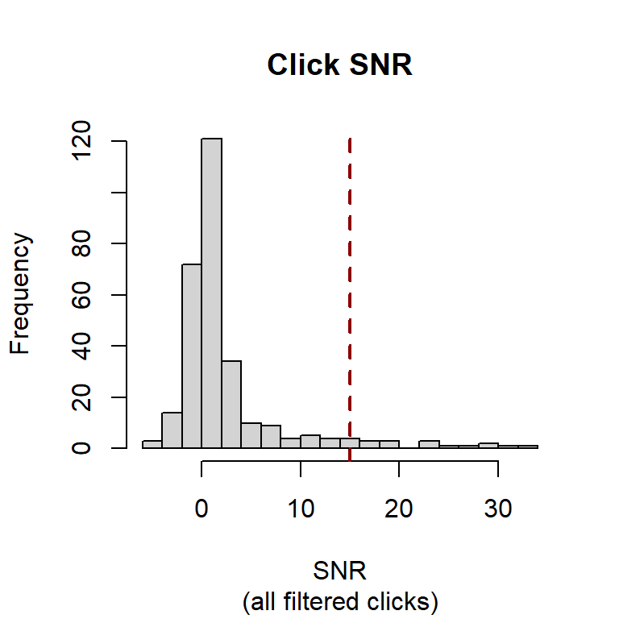

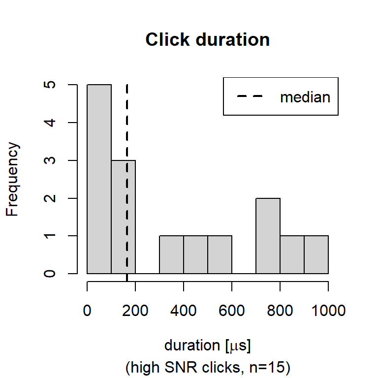

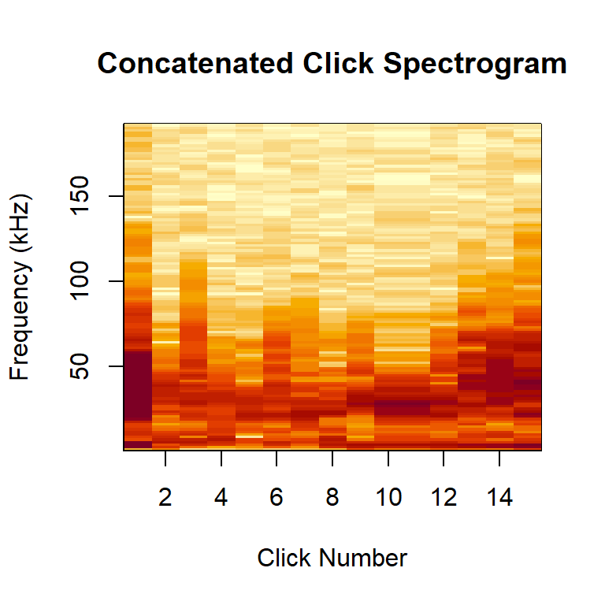

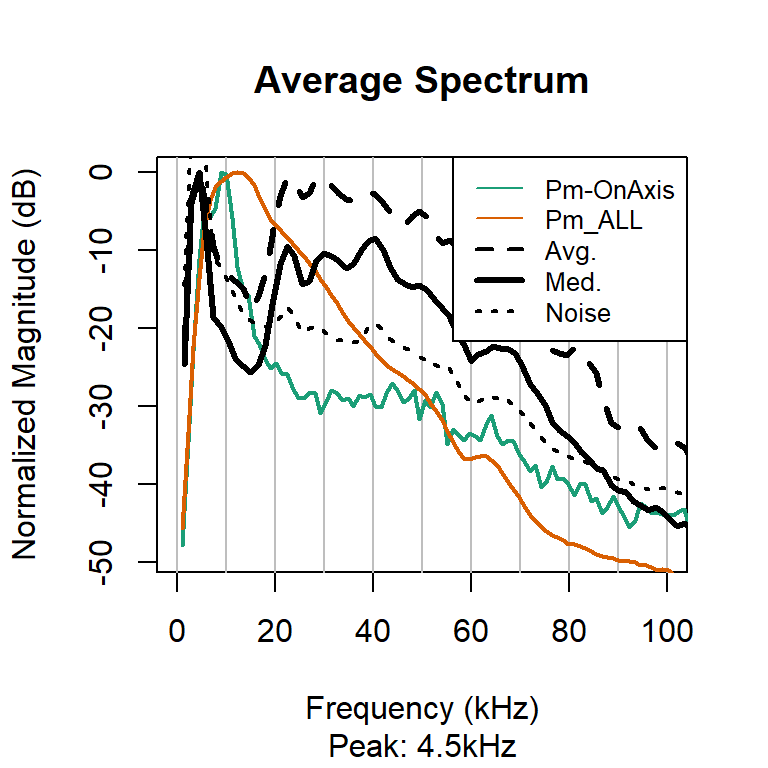

Median statistics for 15 high SNR clicks with SNR >= 15 dB.

| parameter | value |
| --- | --- |
| Median Peak Frequency [kHz] | 20.8 |
| Median 3dB Center Frequency [kHz] | 2.66 |
| Median 10dB Center Frequency [kHz] | 2.72 |
| Median 3dB Bandwidth [kHz] (lower-upper) | 0.558 ( 2.4 - 2.91) |
| Median 10dB Bandwidth [kHz] (lower-upper) | 1.01 (2.26 - 3.18) |
| Median duration [μs] (25-75 percentile) | 167 (38 - 1000) |

#### Event ID: 7519.241003025400.wav

Time: 2024-10-03 02:54UTC to 2024-10-03 02:59UTC

Event contains 990 original clicks, **495 valid clicks** after filtering.

##### Click plots and table

SNR histogram includes all filtered clicks. Other plots contain only clicks with SNR >= 15 dB (**n = 21 clicks**) .

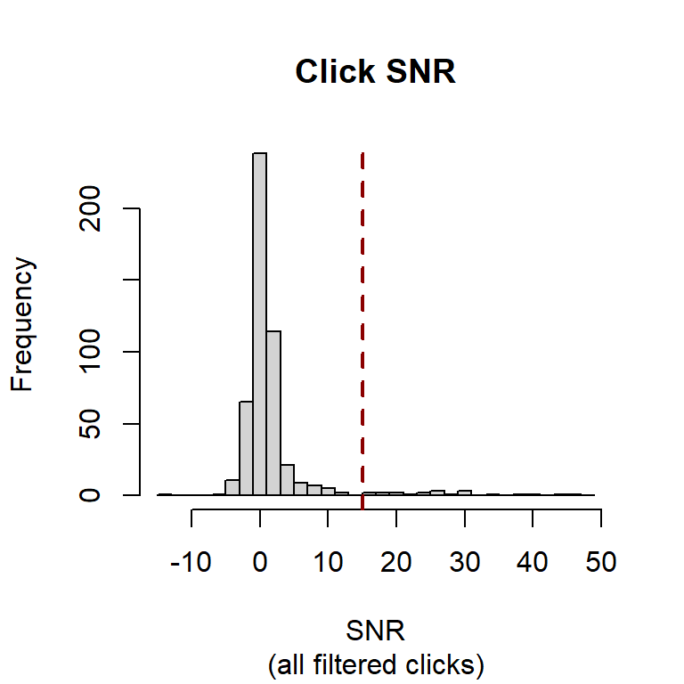

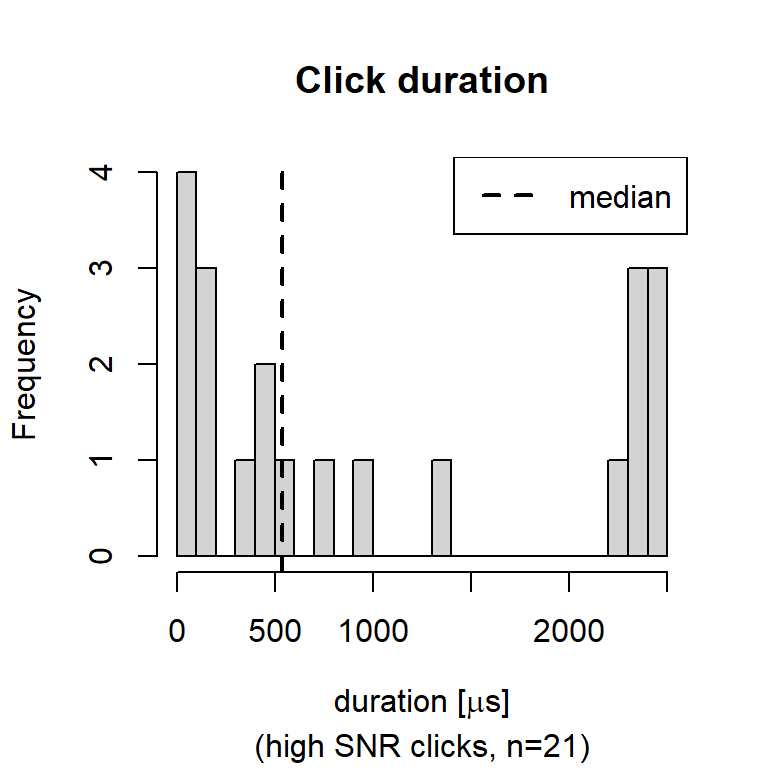

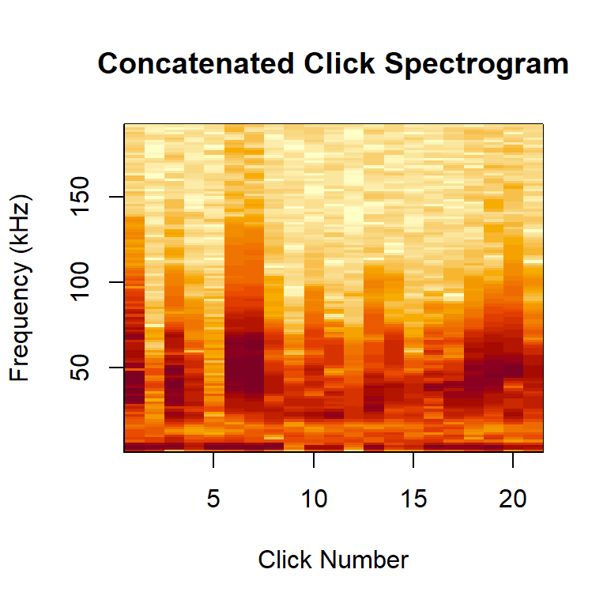

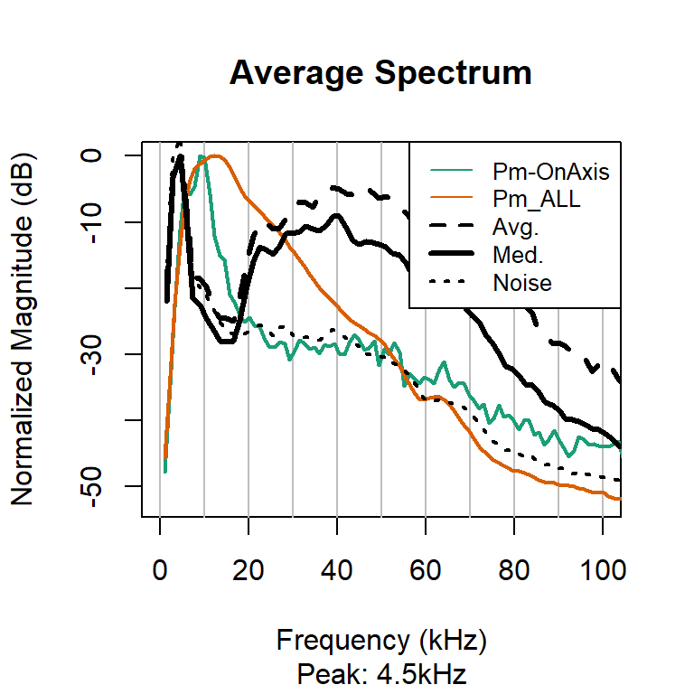

Median statistics for 21 high SNR clicks with SNR >= 15 dB.

| parameter | value |
| --- | --- |
| Median Peak Frequency [kHz] | 37.2 |
| Median 3dB Center Frequency [kHz] | 2.62 |
| Median 10dB Center Frequency [kHz] | 2.64 |
| Median 3dB Bandwidth [kHz] (lower-upper) | 0.541 (2.35 - 2.9) |
| Median 10dB Bandwidth [kHz] (lower-upper) | 0.975 (2.13 - 3.13) |
| Median duration [μs] (25-75 percentile) | 540 (138 - 2310) |

#### Event ID: 7519.241003030000.wav

Time: 2024-10-03 03:00UTC to 2024-10-03 03:06UTC

Event contains 1114 original clicks, **557 valid clicks** after filtering.

##### Click plots and table

SNR histogram includes all filtered clicks. Other plots contain only clicks with SNR >= 15 dB (**n = 18 clicks**) .

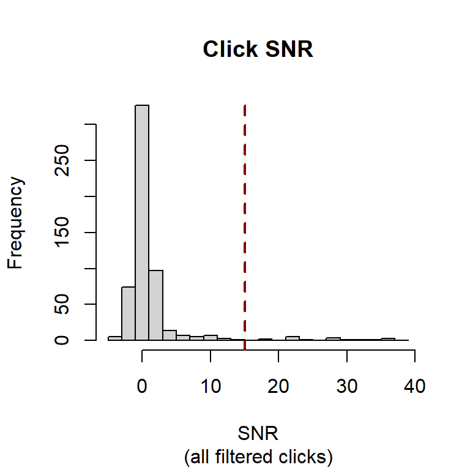

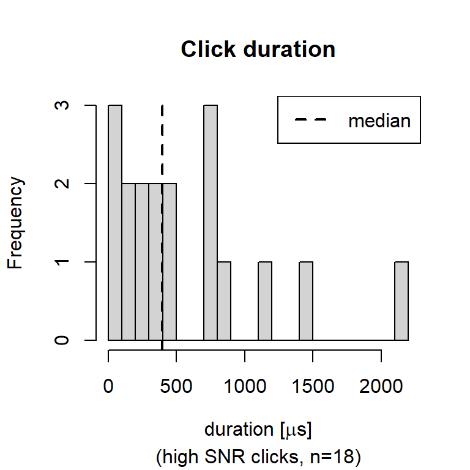

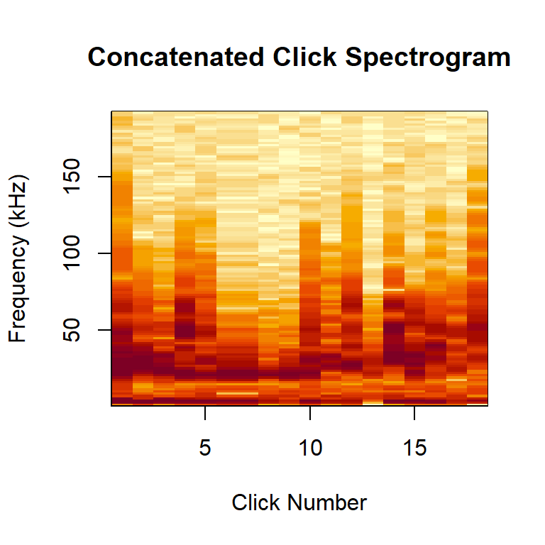

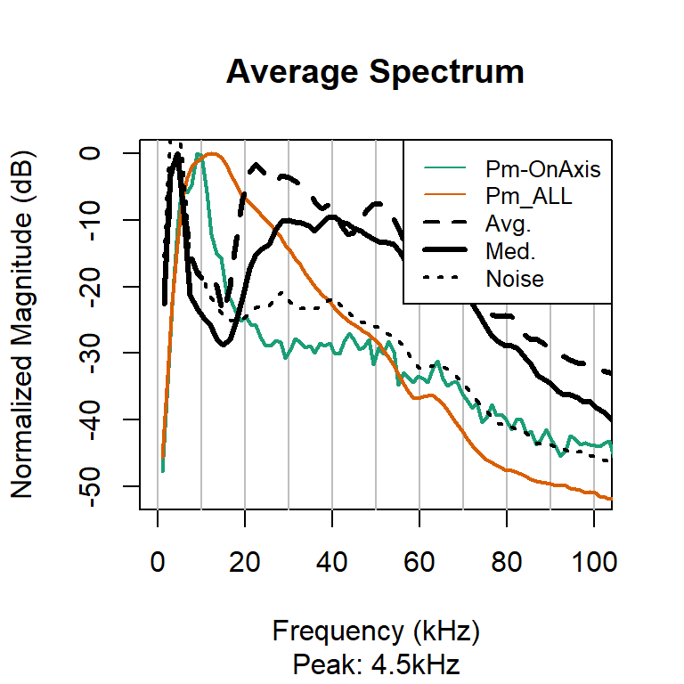

Median statistics for 18 high SNR clicks with SNR >= 15 dB.

| parameter | value |
| --- | --- |
| Median Peak Frequency [kHz] | 21.8 |
| Median 3dB Center Frequency [kHz] | 2.66 |
| Median 10dB Center Frequency [kHz] | 2.72 |
| Median 3dB Bandwidth [kHz] (lower-upper) | 0.522 (2.41 - 2.91) |
| Median 10dB Bandwidth [kHz] (lower-upper) | 0.963 (2.27 - 3.17) |
| Median duration [μs] (25-75 percentile) | 398 (180 - 1000) |

#### Event ID: 7519.241003030600.wav

Time: 2024-10-03 03:06UTC to 2024-10-03 03:12UTC

Event contains 1058 original clicks, **529 valid clicks** after filtering.

##### Click plots and table

SNR histogram includes all filtered clicks. Other plots contain only clicks with SNR >= 15 dB (**n = 27 clicks**) .

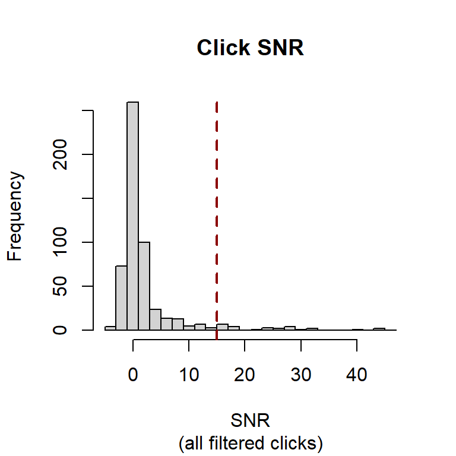

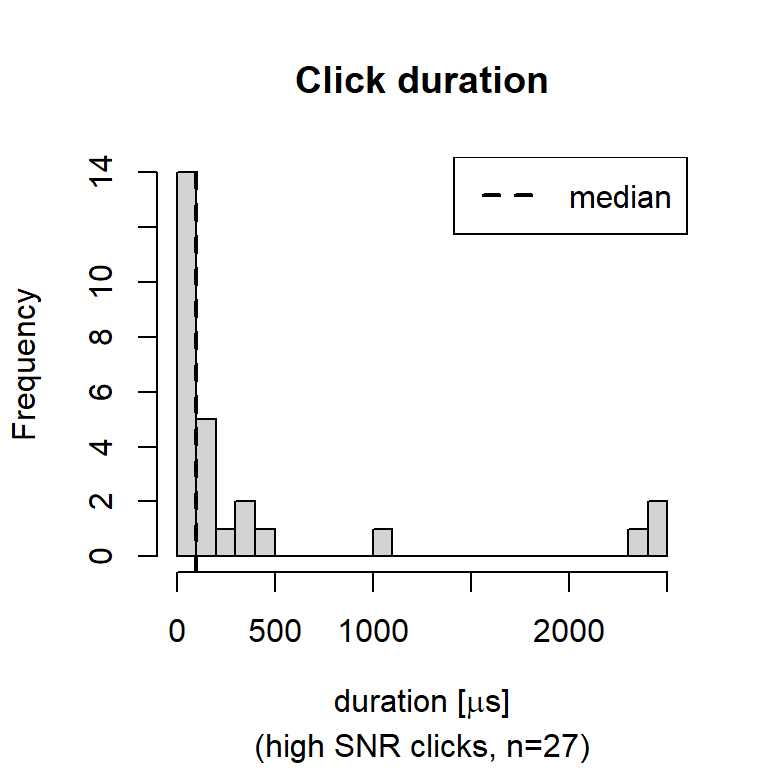

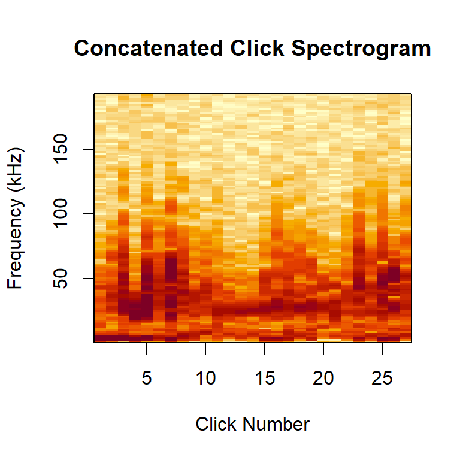

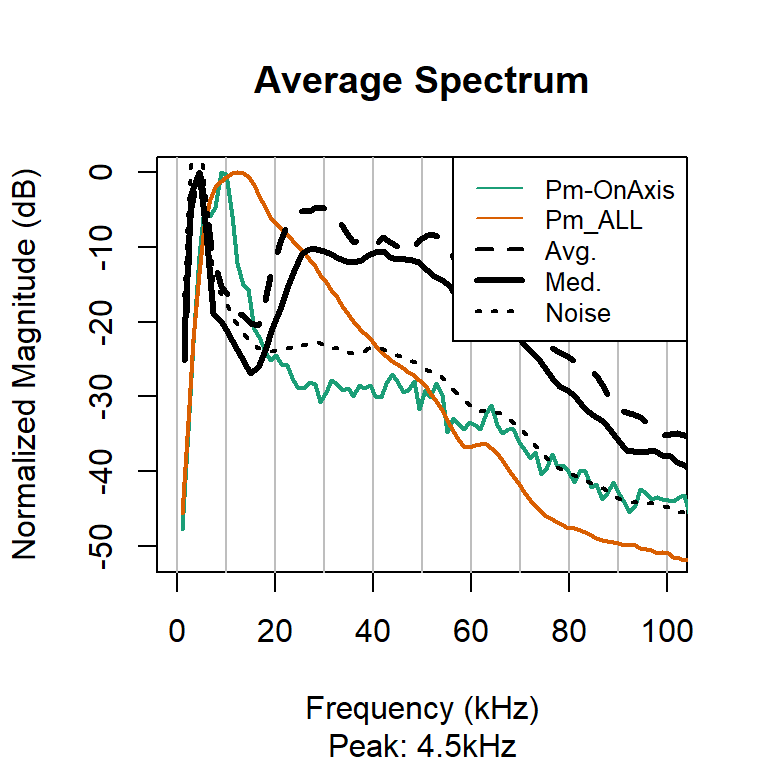

Median statistics for 27 high SNR clicks with SNR >= 15 dB.

| parameter | value |
| --- | --- |
| Median Peak Frequency [kHz] | 21.6 |
| Median 3dB Center Frequency [kHz] | 3.05 |
| Median 10dB Center Frequency [kHz] | 3.11 |
| Median 3dB Bandwidth [kHz] (lower-upper) | 0.544 (2.78 - 3.31) |
| Median 10dB Bandwidth [kHz] (lower-upper) | 1.14 ( 2.5 - 3.84) |
| Median duration [μs] (25-75 percentile) | 99 (50 - 309) |

#### Event ID: 7519.241003031200.wav

Time: 2024-10-03 03:12UTC to 2024-10-03 03:17UTC

Event contains 442 original clicks, **221 valid clicks** after filtering.

##### Click plots and table

SNR histogram includes all filtered clicks. Other plots contain only clicks with SNR >= 15 dB (**n = 13 clicks**) .

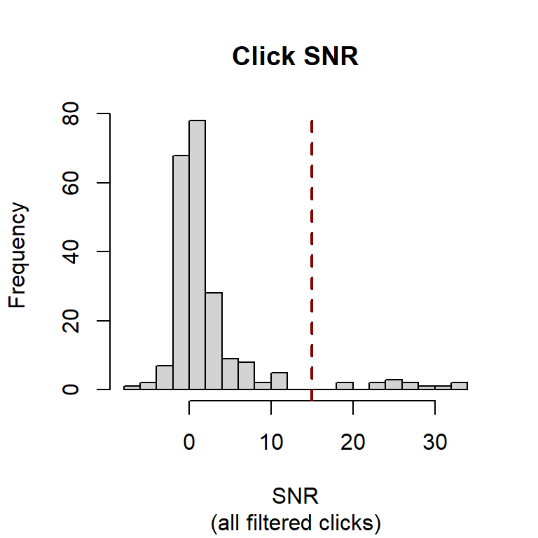

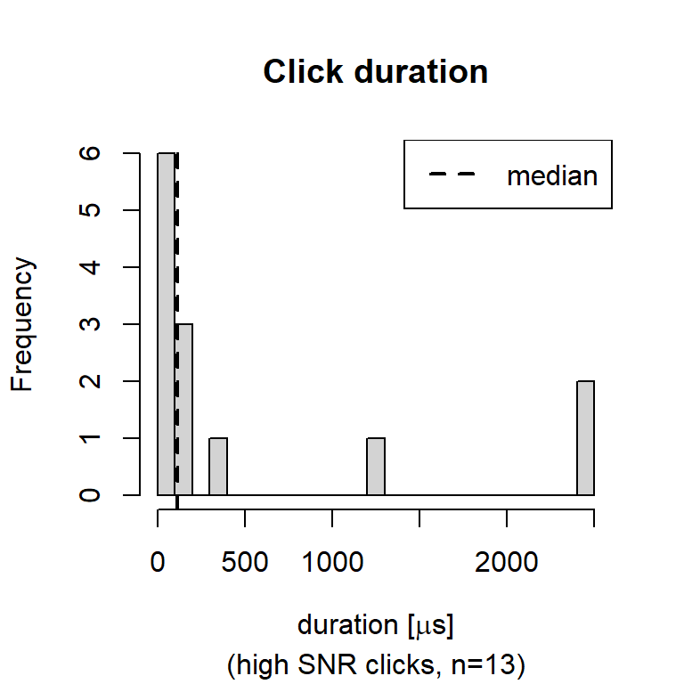

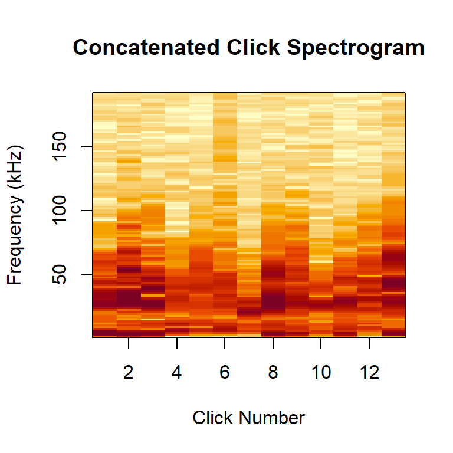

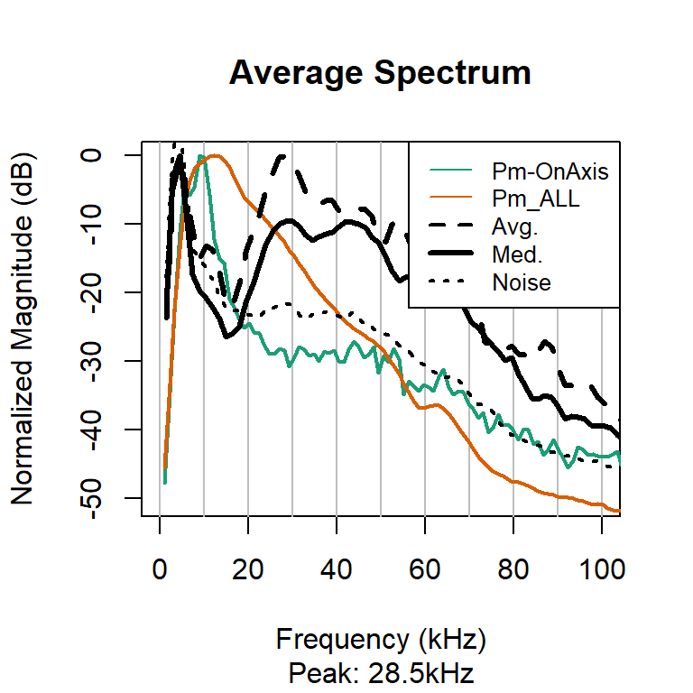

Median statistics for 13 high SNR clicks with SNR >= 15 dB.

| parameter | value |
| --- | --- |
| Median Peak Frequency [kHz] | 25.6 |
| Median 3dB Center Frequency [kHz] | 2.94 |
| Median 10dB Center Frequency [kHz] | 2.89 |
| Median 3dB Bandwidth [kHz] (lower-upper) | 0.566 (2.67 - 3.2) |
| Median 10dB Bandwidth [kHz] (lower-upper) | 1.01 (2.39 - 3.39) |
| Median duration [μs] (25-75 percentile) | 115 (26 - 313) |

#### Event ID: 7519.241003170000.wav

Time: 2024-10-03 17:00UTC to 2024-10-03 17:05UTC

Event contains 498 original clicks, **249 valid clicks** after filtering.

##### Click plots and table

SNR histogram includes all filtered clicks. Other plots contain only clicks with SNR >= 15 dB (**n = 155 clicks**) .

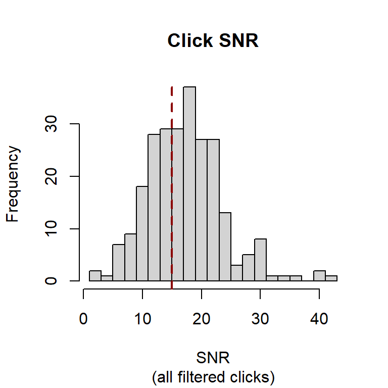

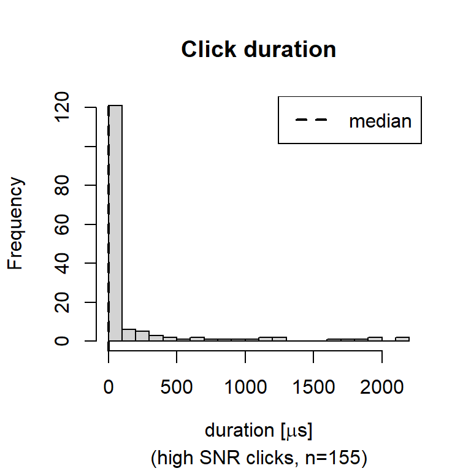

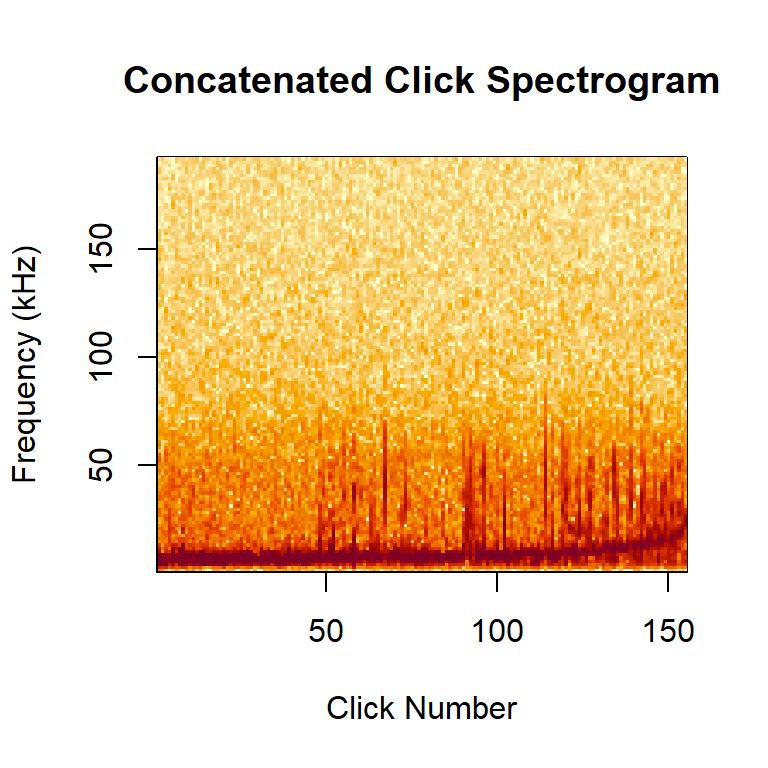

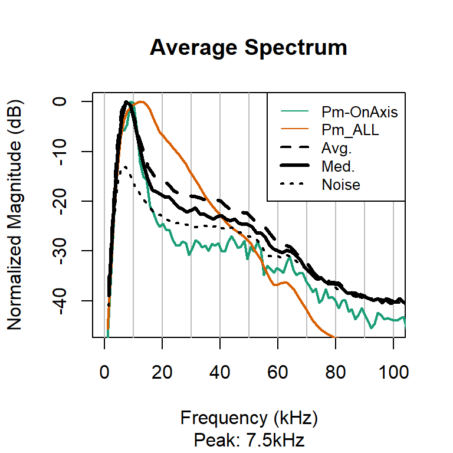

Median statistics for 155 high SNR clicks with SNR >= 15 dB.

| parameter | value |
| --- | --- |
| Median Peak Frequency [kHz] | 6.8 |
| Median 3dB Center Frequency [kHz] | 6.61 |
| Median 10dB Center Frequency [kHz] | 6.67 |
| Median 3dB Bandwidth [kHz] (lower-upper) | 1.13 (5.85 - 7.31) |
| Median 10dB Bandwidth [kHz] (lower-upper) | 3.07 (4.59 - 8.29) |
| Median duration [μs] (25-75 percentile) | 0 (0 - 100) |

#### Event ID: 7519.241004060000.wav

Time: 2024-10-04 06:00UTC to 2024-10-04 06:05UTC

Event contains 1940 original clicks, **970 valid clicks** after filtering.

##### Click plots and table

SNR histogram includes all filtered clicks. Other plots contain only clicks with SNR >= 15 dB (**n = 402 clicks**) .

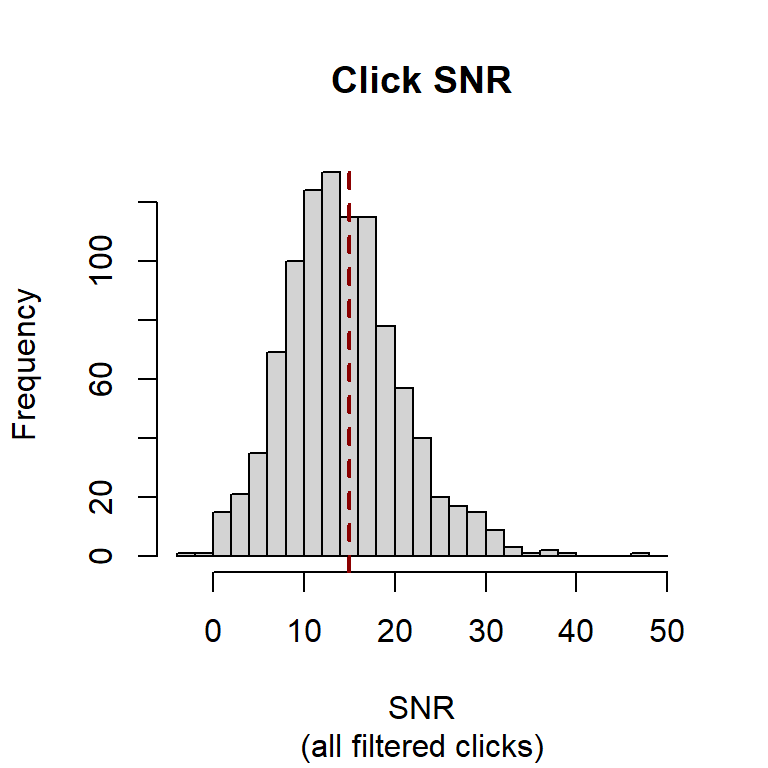

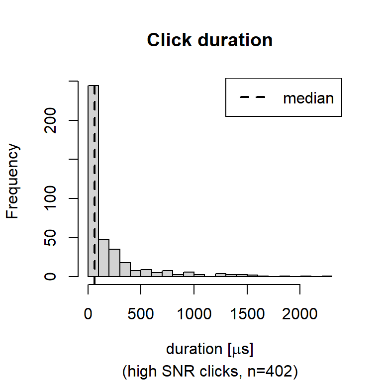

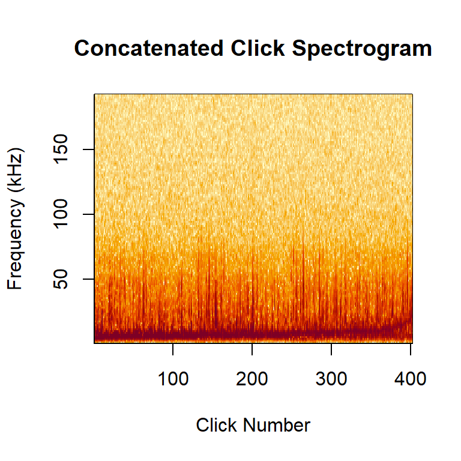

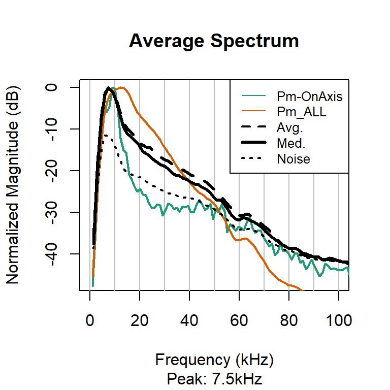

Median statistics for 402 high SNR clicks with SNR >= 15 dB.

| parameter | value |
| --- | --- |
| Median Peak Frequency [kHz] | 6 |
| Median 3dB Center Frequency [kHz] | 5.94 |
| Median 10dB Center Frequency [kHz] | 6.32 |
| Median 3dB Bandwidth [kHz] (lower-upper) | 1.17 (5.26 - 6.67) |
| Median 10dB Bandwidth [kHz] (lower-upper) | 3.96 (3.78 - 8.71) |
| Median duration [μs] (25-75 percentile) | 64 (3 - 212) |

#### Event ID: 7519.241005020601.wav

Time: 2024-10-05 02:06UTC to 2024-10-05 02:12UTC

Event contains 8598 original clicks, **4299 valid clicks** after filtering.

##### Click plots and table

SNR histogram includes all filtered clicks. Other plots contain only clicks with SNR >= 15 dB (**n = 2040 clicks**) .

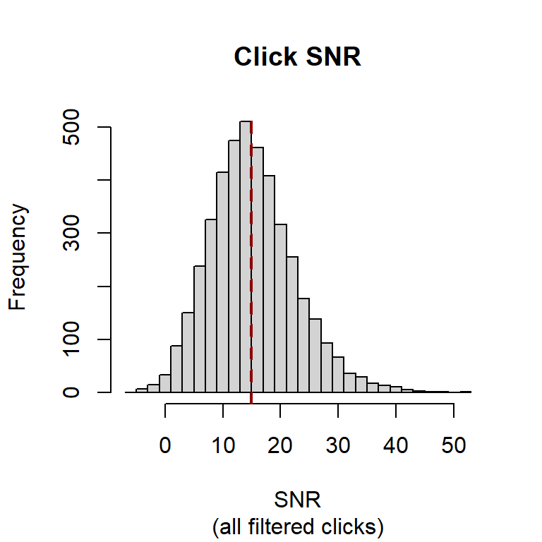

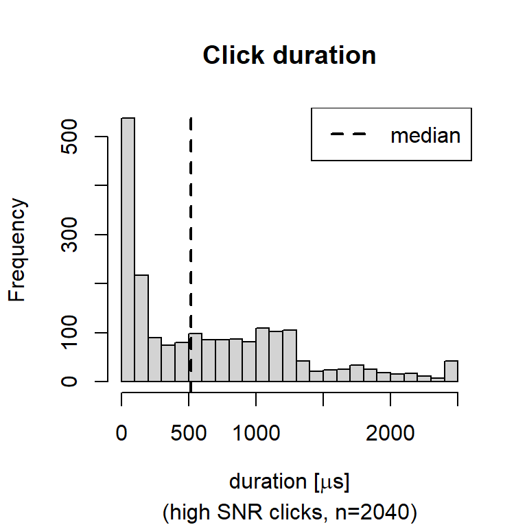

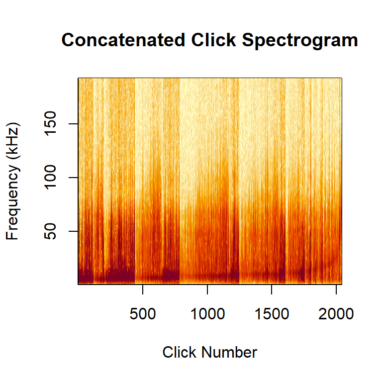

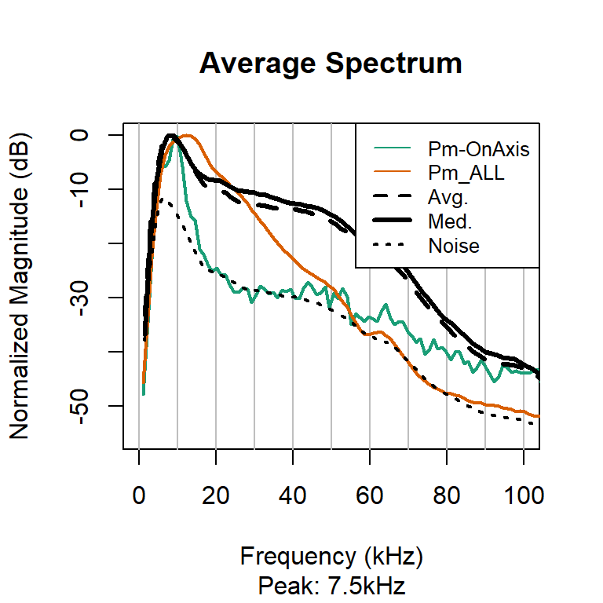

Median statistics for 2040 high SNR clicks with SNR >= 15 dB.

| parameter | value |
| --- | --- |
| Median Peak Frequency [kHz] | 7.2 |
| Median 3dB Center Frequency [kHz] | 6.95 |
| Median 10dB Center Frequency [kHz] | 7.29 |
| Median 3dB Bandwidth [kHz] (lower-upper) | 1.28 (6.09 - 7.73) |
| Median 10dB Bandwidth [kHz] (lower-upper) | 4.92 (4.46 - 9.93) |
| Median duration [μs] (25-75 percentile) | 516 (100 - 1087) |

### Clean up Event Table

```r
# clean up the event table
evTable <- evTable[evTable$keep == TRUE,]
evTable <- subset(evTable, select = -keep)
# save event table as CSV
write.csv(evTable, file = file.path(params$path_dets,
                                    paste0('eventTable_', params$mission, '_',
                                           params$drift, '_', Sys.Date(),'.csv')))

#dbDisconnect(dbFile)
```

After additional filtering based on median peak frequency, **8 events** events of **712 original events** remain.